# Lab 1 - Path Models, Indirect Effects, and Single Indicator Factors

Structural Equation Modeling ED 216F - Instructor: Karen Nylund-Gibson

Adam Garber

April 03, 2020

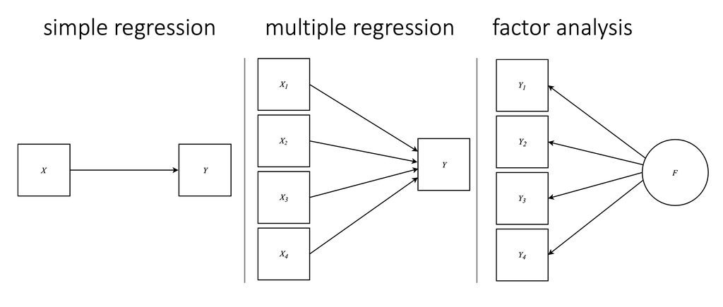

#### DATA SOURCE: This lab exercise utilizes the NCES public-use dataset: Education Longitudinal Study of 2002 (Lauff & Ingels, 2014) [$\color{blue}{\text{See website: nces.ed.gov}}$](https://nces.ed.gov/surveys/els2002/avail_data.asp)

#### $\color{purple}{\text{Tools for reproducibility:}}$

| Tool/Package | Purpose/Utility | Advantages |
| --- | --- | --- |
| {MplusAutomation} package | Current capabilities supporting full SEM modeling | High flexibility |
| R Project | Unbreakable file paths & neatness | Reproducibility (kindness to your future self) |
| {tidyverse} package | Intuitive/descriptive function names | Accessibility to new users |
| {here} package | Unbreakable/consistent file paths across OS | Reproducibility (for Science’s sake!) |
| {haven} package | View-able metadata in R from SPSS data-files | Getting to know your measures |
| {ggplot2} package | Clear, customizable, reproducible figures | Publication quality data visualizations |
| pipe operator (%>%) notation | Ease of reading/writing scripts | e.g., first() %>% and_then() %>% and_finally() |

### $\color{purple}{\text{Creating a version-controlled R-Project by downloading repository from Github}}$

Download ropository here: $\color{blue}{\text{https://github.com/garberadamc/SEM-Lab1}}$

#### Create a class folder (to save labs and assignments)

1. click “NEW PROJECT” (upper right corner of window)
2. choose option **Version Control**
3. choose option **Git**
4. paste the repository web URL path coppied from the `clone or download` button on the repo page
5. choose location of the R-Project ($\color{red}{\text{too many nested folders will result in filepath error}}$)

#### Create sub-folders within the project folder. In R-studio under the files pane …

1. click “New Folder” and name folder “data”
2. click “New Folder” and name folder “mplus_files”
3. click “New Folder” and name folder “figures”

Install the “rhdf5” package to read gh5 files

```r
if (!requireNamespace("BiocManager", quietly = TRUE))
    install.packages("BiocManager")
 BiocManager::install("rhdf5")
```

### $\color{purple}{\text{Load packages}}$

```r
library(MplusAutomation)
library(haven)
library(rhdf5)
library(tidyverse)
library(here)
library(corrplot)
library(kableExtra)
library(reshape2)
library(janitor)
library(ggridges)
library(DiagrammeR)
library(semPlot)
library(sjPlot)
```

Keyboard shortcuts

- ALT + DASH(-) = **<-**
- SHIFT + CONTROL = **%>%**

### $\color{purple}{\text{Read in SPSS data}}$

```r
spss_data <- read_spss(here("data", "els_sub1_spss.sav")) %>%
  janitor::clean_names() # makes all variable names lowercase
```

### $\color{purple}{\text{Preparations: subset, rename, and reorder columns}}$

1. **subset:** select columns in 3 ways, remove columns with (-), select by index number, and select by column name
2. **rename:** change variable names to be descriptive and within the Mplus 8 character limit
3. **reorder:** this makes it easy to choose sequential variables for {MplusAutomation}

```r
spss_sub0 <- spss_data %>%
  select(-stu_id,   -sch_id,   -byrace,
         -byparace, -byparlng, -byfcomp,
         -bypared,  -bymothed, -byfathed,
         -bysctrl,  -byurban,  -byregion)
```

### $\color{purple}{\text{Select the first 9 columns (by index) and select the next 17 columns (by name)}}$

```r
spss_sub1 <- spss_sub0 %>%
  select(1:9,
         bys20a, bys20h, bys20j, bys20k, bys20m, bys20n,
         bys21b, bys21d, bys22a, bys22b, bys22c, bys22d,
         bys22e, bys22g, bys22h, bys24a, bys24b) %>%
  rename("stu_exp" = "bystexp",   # "NEW_NAME" = "OLD_NAME"
         "par_asp" = "byparasp",
         "mth_read" = "bytxcstd",
         "mth_test" = "bytxmstd",
         "rd_test" = "bytxrstd",
         "freelnch" = "by10flp",
         "stu_tch" = "bys20a",
         "putdownt" = "bys20h",
         "unsafe" = "bys20j",
         "disrupt" = "bys20k",
         "gangs" = "bys20m",
         "rac_fght" = "bys20n",
         "fair" = "bys21b",
         "strict" = "bys21d",
         "stolen" = "bys22a",
         "drugs" = "bys22b",
         "t_hurt" = "bys22c",
         "p_fight" = "bys22d",
         "hit" = "bys22e",
         "damaged" = "bys22g",
         "bullied" = "bys22h",
         "late" = "bys24a",
         "skipped" = "bys24b")
```

### $\color{purple}{\text{More housekeeping: reorder columns }}$

```r
spss_sub2 <-  spss_sub1 %>%
  select(
    bystlang,                                        # dichotomous (yes,no)
    freelnch, byincome,                              # ordinal (binned, continuous scale)
    stolen, t_hurt, p_fight, hit, damaged, bullied,  # ordinal frequency (3-point)
    unsafe, disrupt, gangs, rac_fght,                # ordinal Likert (4-point scale)
    late, skipped,                                   # ordinal frequency (4-point scale)
    mth_test, rd_test)                               # continuous (standardized test scores)
```

### $\color{purple}{\text{Make a codebook including metadata using {`sjPlot`}}}$

```r
sjPlot::view_df(spss_sub2)
```

### $\color{purple}{\text{Types of data for different tasks}}$

- SAV (e.g., spss_data.sav): this data format is for SPSS files & contains variable labels (meta-data)
- CSV (e.g., r_ready_data.csv): this is the preferable data format for reading into R (no labels)
- DAT (e.g., mplus_data.dat): this is the data format used to read into Mplus (no column names or strings)

NOTE: Mplus also accepts TXT formatted data (e.g., mplus_data.txt)

### $\color{purple}{\text{Converting data between 3 formats: writing and reading data}}$

Write a CSV datafile (preferable format for reading into R, with SPSS labels removed)

```r
write_csv(spss_sub2, here("data", "els_sub6_data.csv"))
```

Write a SPSS datafile (preferable format for reading into SPSS, labels are preserved)

```r
write_sav(spss_sub2, here("data", "els_sub6_data.sav"))
```

Read the unlabeled data back into R

```r
tidy_data <- read_csv(here("data", "els_sub6_data.csv"))
```

Write a DAT datafile for Mplus (this function removes header row & converts missing values to non-string)

```r
prepareMplusData(tidy_data, here("data", "els_sub6_data.dat"))
```

### $\color{purple}{\text{Make a `tribble` table}}$

```r
var_table <- tribble(
   ~"Name",    ~"Labels",                                      ~"Value Labels (limit)",
 #-----------|-----------------------------------------------|--------------------------------------|,
  "bystlang" , "Whether English is students native language" ,"0=No, 1=Yes",
  "freelnch" , "Grade 10 percent free lunch-categorical"     ,"0=0-5%, 7=76-100%",
  "byincome" , "Total family income from all sources 2001"   ,"1=None, 13=$200,001 or more",
  "stolen"   , "Had something stolen at school"              ,"1=Never, 3=More than twice",
  "t_hurt"   , "Someone threatened to hurt 10th grader at school","1=Never, 3=More than twice",
  "p_fight"  , "Got into a physical fight at school"         ,"1=Never, 3=More than twice"  ,
  "hit"      , "Someone hit 10th grader"                     ,"1=Never, 3=More than twice"  ,
  "damaged"  , "Someone damaged belongings"                  ,"1=Never, 3=More than twice"  ,
  "bullied"  , "Someone bullied or picked on 10th grader"    ,"1=Never, 3=More than twice"  ,
  "unsafe"   , "Does not feel safe at this school"           ,"1=Strongly agree, 4=Strongly disagree"  ,
  "disrupt"  , "Disruptions get in way of learning"          ,"1=Strongly agree, 4=Strongly disagree"  ,
  "gangs"    , "There are gangs in school"                   ,"1=Strongly agree, 4=Strongly disagree"  ,
  "rac_fght" , "Racial-ethnic groups often fight"            ,"1=Strongly agree, 4=Strongly disagree"  ,
  "late"     , "How many times late for school"              ,"1=Never, 4=10 or more times"  ,
  "skipped"  , "How many times cut-skip classes"             ,"1=Never, 4=10 or more times"  ,
  "mth_test" , "Math test standardized score"                ,"0-100"  ,
  "rd_test"  , "Reading test standardized score"             ,"0-100"  ,
)

var_table %>%
  kable("latex", booktabs = T, linesep = "") %>%
  kable_styling(latex_options = c("striped"),
                full_width = F,
                position = "left")
```

### $\color{purple}{\text{Take a look at the data - some practice with {`ggplot2`}}}$

Make a facetted box plot

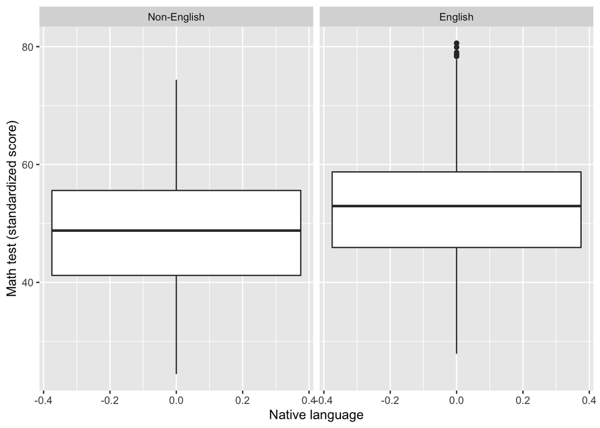

```r
# some formatting, add labels to `bystlang` for plot
tidy_data <- tidy_data %>%
  mutate(
    bystlang = factor(bystlang,
    labels = c(`0` = "Non-English", `1` = "English")))


  ggplot(data=drop_na(tidy_data), aes(y=mth_test)) +
    geom_boxplot() +
    facet_wrap(~bystlang) +
    labs(x = "Native language",
         y = "Math test (standardized score)")
```

Make a density plot

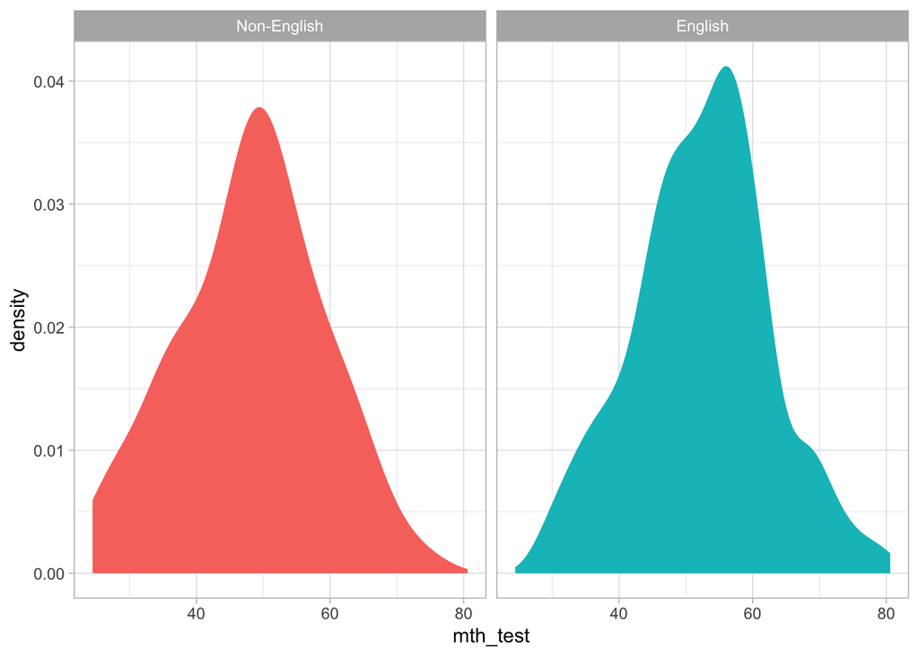

```r
  ggplot(data=drop_na(tidy_data), aes(x=mth_test)) +
    geom_density(aes(fill = bystlang),
                 color = NA,
                 show.legend = FALSE) +
    facet_wrap(~bystlang) +
    theme_light()
```

Ridgeline plot {`ggridges`}

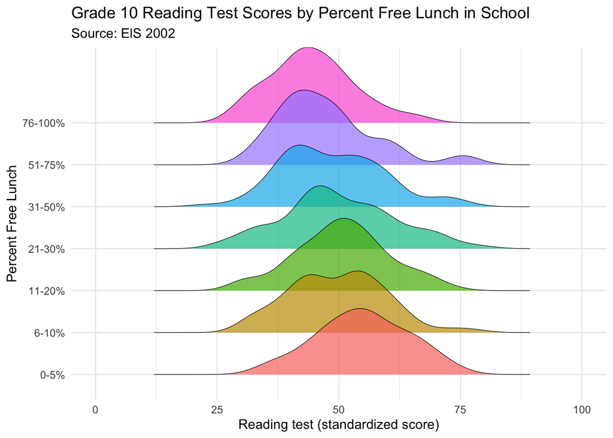

```r
# A ridgeline plot is good way to compare distributions across groups.
# In the plot below the distribution of reading test scores is grouped
# by level of the freelunch variable.

ridge_graph <- ggplot(data = drop_na(tidy_data),
                      aes(x = rd_test, y = factor(freelnch))) +
  geom_density_ridges(aes(fill = factor(freelnch)),
                      size = 0.2,
                      alpha = 0.7,
                      show.legend = FALSE) +
  scale_x_continuous(lim = c(0,100)) +
    scale_y_discrete(lim = levels(tidy_data$freelnch),
                   labels = c("0-5%", "6-10%", "11-20%","21-30%",
                              "31-50%", "51-75%", "76-100%")) +
    labs(x = "Reading test (standardized score)",
         y = "Percent Free Lunch",
     title = "Grade 10 Reading Test Scores by Percent Free Lunch in School",
  subtitle = "Source: ElS 2002") +
  theme_minimal()

ridge_graph
```

### $\color{purple}{\text{Look at all bivariate relations}}$

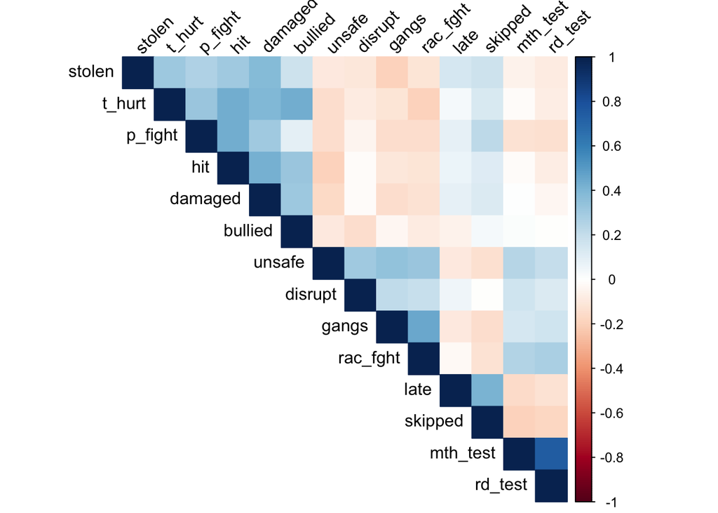

```r
t_cor <- cor(tidy_data[,4:17], use = "pairwise.complete.obs")

corrplot(t_cor,
         method = "color",
         type = "upper",
         tl.col="black",
         tl.srt=45)
```

### $\color{purple}{\text{Run some path models with {MplusAutomation}}}$

Practice run, use `type=basic` to get descriptives

```r
m_basic  <- mplusObject(
  TITLE = "RUN TYPE = BASIC ANALYSIS - LAB 1",
  VARIABLE =
    " ! an mplusObject() will always need a 'usevar' statement
      ! ONLY specify variables that will be used in analysis
      ! lines of code in MPLUS ALWAYS end with a semicolon ';'
    usevar =
    bystlang freelnch byincome stolen t_hurt p_fight
    hit damaged bullie, unsafe disrupt gangs rac_fght
    late skipped mth_test rd_test;",

  ANALYSIS =
    "type = basic" ,

  MODEL = "" ,

  PLOT = "",

  OUTPUT = "",

  usevariables = colnames(tidy_data),   # tell MplusAutomation the column names to use
  rdata = tidy_data)                    # this is the data object used (must be un-label)

m_basic_fit <- mplusModeler(m_basic,
                    dataout=here("mplus_files", "Lab1.dat"),
                    modelout=here("mplus_files", "m0_basic_Lab1.inp"),
                    check=TRUE, run = TRUE, hashfilename = FALSE)
```

### $\color{purple}{\text{Run a path model with model indirect (to estimate the indirect effect) }}$

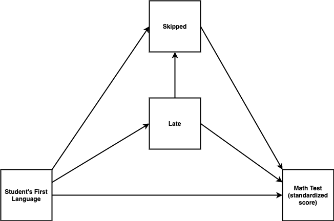

*Figure 1*. Path Diagram of Multiple Indirect Paths Model

Visualize the path diagram using the {`DiagrammeR`} package

```r
mermaid("
graph LR
  bystlang-->late
  bystlang-->skipped
  bystlang-->mth_test
  late-->skipped
  late-->mth_test
  skipped-->mth_test
")
```

[output not shown]

Run model depicted above with multiple indirect paths

```r
m1_ind  <- mplusObject(
  TITLE = "m1 model indirect - Lab 1",
  VARIABLE =
   "usevar =
    bystlang       ! covariate
    late skipped   ! mediators
    mth_test;      ! outcome   ",

  ANALYSIS =
    "estimator = MLR" ,

  MODEL =
   "late on bystlang ;
    skipped on late bystlang ;
    mth_test on late skipped bystlang;

    Model indirect:
    mth_test ind bystlang;
    mth_test via late skipped bystlang; " ,

  OUTPUT = "sampstat standardized",

  usevariables = colnames(tidy_data),
  rdata = tidy_data)

m1_ind_fit <- mplusModeler(m1_ind,
                     dataout=here("mplus_files", "Lab1.dat"),
                    modelout=here("mplus_files", "m1_indirect_Lab1.inp"),
                    check=TRUE, run = TRUE, hashfilename = FALSE)
```

Generate a path diagram from Mplus output with {`semPlot`}

```r
order2_model <- readModels(here("mplus_files",
                                "m1_indirect_Lab1.out"))

# plot model:
semPaths(order2_model,
          intercepts=FALSE)
```

[output not shown]

### $\color{purple}{\text{Single indicator factors}}$

Model specifications:

- Fix the loading to 1
- Then fix the residual variance to a specific value (you are not estimating a measurement parameter)

Using reliability you fix the residual variance at:

$(1‐reliabilty) *variance$

Lab example of single indicator factor model:

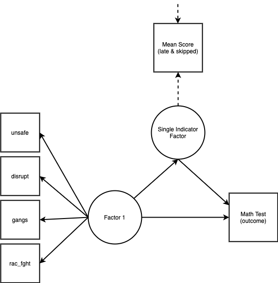

*Figure 2*. Path Diagram of Single Indicator Factor Model

```r
tidy_data2 <- tidy_data %>%
  mutate(mean_scr = rowSums(select(., late:skipped))/2)
```

- Reliability = .8 (set to)
  - Variance = .77 (mean_score)

Function to fix the residual variance

```r
# r = reliability, v = variance

resid_var <- function(r,v) {

 y <- ((1-r)*v)
    return(y)
}

y01 <- resid_var(.8,.77)

print(y01)
```

```
## [1] 0.154
```

Run model with single indicator factor

```r
m2_sif  <- mplusObject(
  TITLE = "m2 single indicator factor - Lab 1",
  VARIABLE =
   "usevar =
    unsafe disrupt gangs rac_fght  ! factor 1
    mth_test                       ! outcome
    mean_scr;                      ! mediator ",

  ANALYSIS =
    "estimator = MLR" ,

  MODEL =
   "! measurement model
    factor1 by unsafe, disrupt, gangs, rac_fght;

    SIF by mean_scr@1; ! fix factor loading to 1

    mean_scr@.154;     ! fix residual variance

    ! structural model
    mth_test on factor1 SIF;
    SIF on factor1; ",

  OUTPUT = "sampstat standardized",

  usevariables = colnames(tidy_data2),
  rdata = tidy_data2)

m2_sif_fit <- mplusModeler(m2_sif,
                     dataout=here("mplus_files", "Lab1.dat"),
                    modelout=here("mplus_files", "m2_sif_Lab1.inp"),
                    check=TRUE, run = TRUE, hashfilename = FALSE)
```

Generate a path diagram from Mplus output with {`semPlot`}

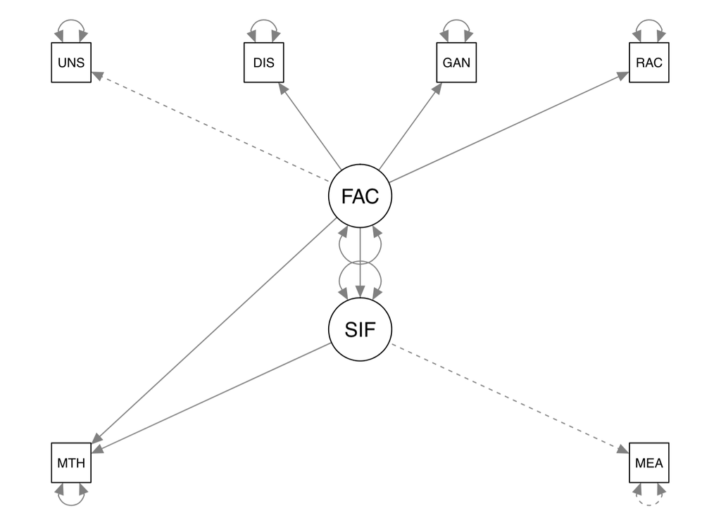

```r
order2_model <- readModels(here("mplus_files",
                                "m2_sif_Lab1.out"))

# plot model:
semPaths(order2_model,
          intercepts=FALSE)
```

### $\color{purple}{\text{References}}$

Hallquist, M. N., & Wiley, J. F. (2018). MplusAutomation: An R Package for Facilitating Large-Scale Latent Variable Analyses in Mplus. Structural equation modeling: a multidisciplinary journal, 25(4), 621-638.

Horst, A. (2020). Course & Workshop Materials. GitHub Repositories, https://https://allisonhorst.github.io/

Muthén, L.K. and Muthén, B.O. (1998-2017). Mplus User’s Guide. Eighth Edition. Los Angeles, CA: Muthén & Muthén

R Core Team (2017). R: A language and environment for statistical computing. R Foundation for Statistical Computing, Vienna, Austria. URL http://www.R-project.org/

Wickham et al., (2019). Welcome to the tidyverse. Journal of Open Source Software, 4(43), 1686, https://doi.org/10.21105/joss.01686